# Random Walk Generator

Juan Felipe Contreras

```r
# libreries
library(ggplot2)
library(devtools)
```

A time series $Y_t$ is said to follow a random walk if the change in $Y_t$ is identical and independently distributed. This is:

$$Y_t = Y_{t-1} + u_t$$

which implies that:
$$\Delta Y_t = Y_t - Y_{t-1} = u_{t}$$

and $u_t \sim N(0,\sigma^2)$. It is assumed that $E(u_{t} \vert Y_{t-1}, y_{t-1},...) = 0$.

In brief, the general idea of a random walk is that the value of the series at a given period $t$ is equal to its value at $t-1$ plus a random value. This implies that the value of the serie is unpredictable, hence it is a random wak.

## Let’s simulate some simple random walk

As explained above, $u_{t}$ follows a normal distribution. Thus, we have:

```r
set.seed(1245) # set the simulation seed
u <- rnorm(1000) # a normal distribution of length 1000
y <- rnorm(1000) # let's assume that y also follows a normal distribution
```

Now, for $Y_{t}$ to follow a random walk, we must have that:

```r
for(t in 2:1000){

  # the value of y at time t is equal of its previous value plus a random term
  y[t] <- y[t-1] + u[t]
}
```

Let’s plot the result:

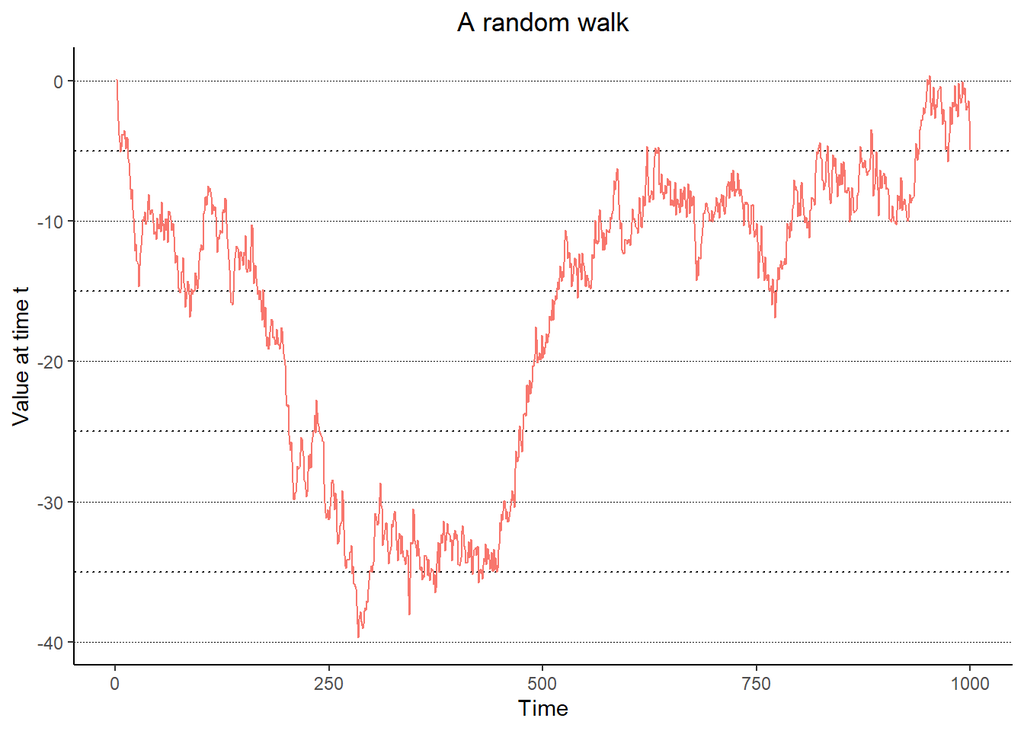

```r
y <- data.frame(y,
                time = 1:1000)
ggplot(data = y,
       aes(x = time,
           y = y)) +
  geom_line(aes(color = "darkred"),
            show.legend = F) +
  theme_classic() +
  xlab("Time") +
  ylab("Value at time t") +
  labs(title = "A random walk") +
  theme(
    panel.grid.major.y = element_line(color = "black",
                                      linetype = "dotted",
                                      size = 0.1),
    panel.grid.minor.y = element_line(color = "black",
                                      linetype = "dotted"),
    plot.title = element_text(hjust = 0.5)
  )
```

# Random Walk Generator

Juan Felipe Contreras

```r
# libreries
library(ggplot2)
library(devtools)
```

A time series $Y_t$ is said to follow a random walk if the change in $Y_t$ is identical and independently distributed. This is:

$$Y_t = Y_{t-1} + u_t$$

which implies that:
$$\Delta Y_t = Y_t - Y_{t-1} = u_{t}$$

and $u_t \sim N(0,\sigma^2)$. It is assumed that $E(u_{t} \vert Y_{t-1}, y_{t-1},...) = 0$.

In brief, the general idea of a random walk is that the value of the series at a given period $t$ is equal to its value at $t-1$ plus a random value. This implies that the value of the serie is unpredictable, hence it is a random wak.

## Let’s simulate some simple random walk

As explained above, $u_{t}$ follows a normal distribution. Thus, we have:

```r
set.seed(1245) # set the simulation seed
u <- rnorm(1000) # a normal distribution of length 1000
y <- rnorm(1000) # let's assume that y also follows a normal distribution
```

Now, for $Y_{t}$ to follow a random walk, we must have that:

```r
for(t in 2:1000){

  # the value of y at time t is equal of its previous value plus a random term
  y[t] <- y[t-1] + u[t]
}
```

Let’s plot the result:

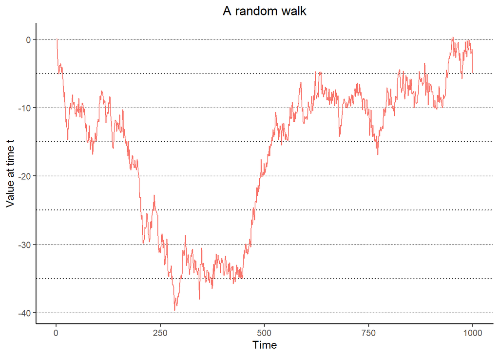

```r
y <- data.frame(y,
                time = 1:1000)
ggplot(data = y,
       aes(x = time,
           y = y)) +
  geom_line(aes(color = "darkred"),
            show.legend = F) +
  theme_classic() +
  xlab("Time") +
  ylab("Value at time t") +
  labs(title = "A random walk") +
  theme(
    panel.grid.major.y = element_line(color = "black",
                                      linetype = "dotted",
                                      size = 0.1),
    panel.grid.minor.y = element_line(color = "black",
                                      linetype = "dotted"),
    plot.title = element_text(hjust = 0.5)
  )
```